# HW4

박효선 1585063

2018년 10월 12일

```r
library(tidyverse)
```

# 1.

### mpg 자료의 displ과 hwy를 이용하여 아래의 그림을 그리기 위한 code를 작성하시오.. 분수를 나타내기 위해 frac(miles, gallon))를 이용하면 됨.

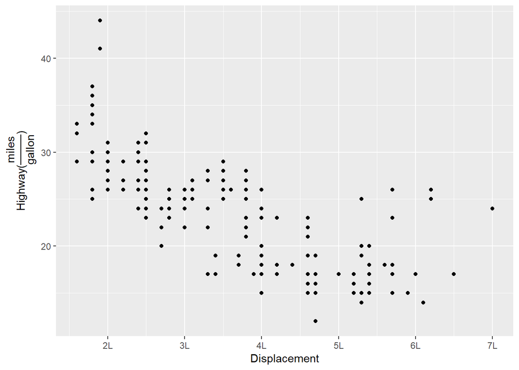

```r
ggplot(mpg, aes(displ, hwy)) + geom_point() +
  ylab(quote(paste("Highway","(",frac(miles,gallon),")")))+
  xlab("Displacement") +
  scale_x_continuous(breaks= c(2,3,4,5,6,7), labels= paste0(c(2,3,4,5,6,7),"L"))
```

# 2.

### 아래의 code를 실행시키고 문제점을 파악한 후 문제점을 수정한 그림을 그리시오.

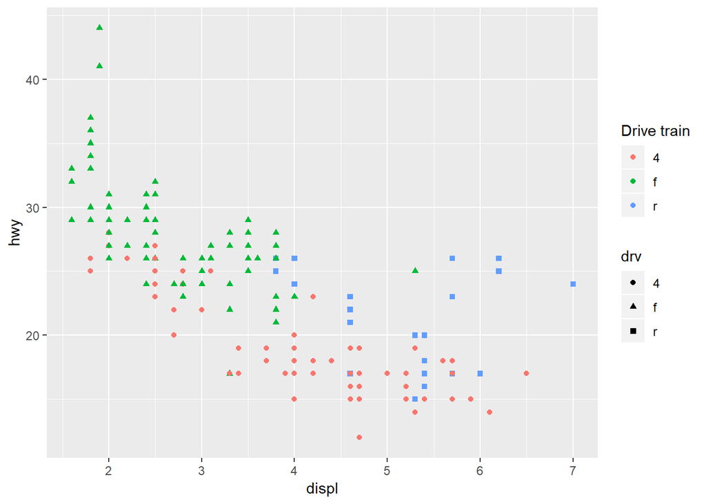

```r
####문제코드
ggplot(mpg,aes(displ,hwy))+
  geom_point(aes(colour=drv,shape=drv))+
  scale_colour_discrete("Drive train")
```

- 문제점::
- Drive train 범례가 같은 단위임에도 불구하고 색깔별 범례와 모양별 범례가 각각 그려져 있어 전달하는데 문제가 있다.

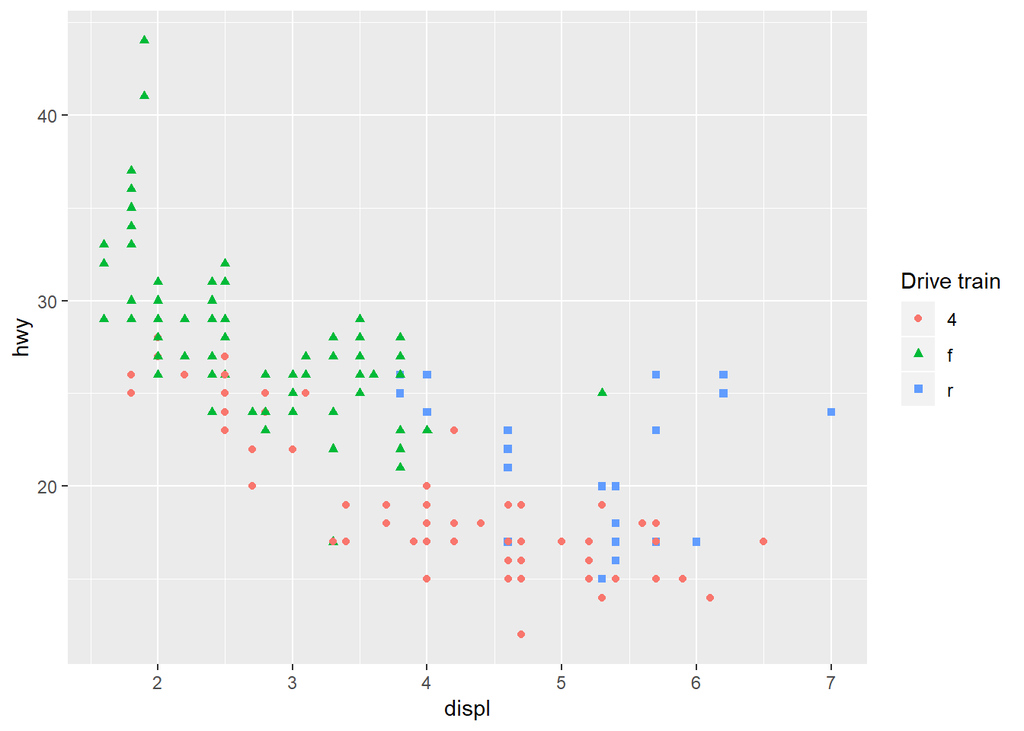

```r
##해결
ggplot(mpg, aes(displ, hwy, color= drv)) +
  geom_point(aes(shape= drv), show.legend = TRUE) +
  scale_colour_discrete("Drive train") +
  scale_shape_discrete("Drive train")
```

- 해결::
- 모양과 색깔을 한번에 적용한 하나의 범주로 통일했다.

# 3.

### mpg 자료에서 drv 별로 cyl와 hwy의 분포를 알아보려고 한다. 이를 위한 다양한 그림을 그리고 설명하시오

```r
#drv 별로 cyl의 분포
table(mpg$cyl)
```

```
##
##  4  5  6  8
## 81  4 79 70
```

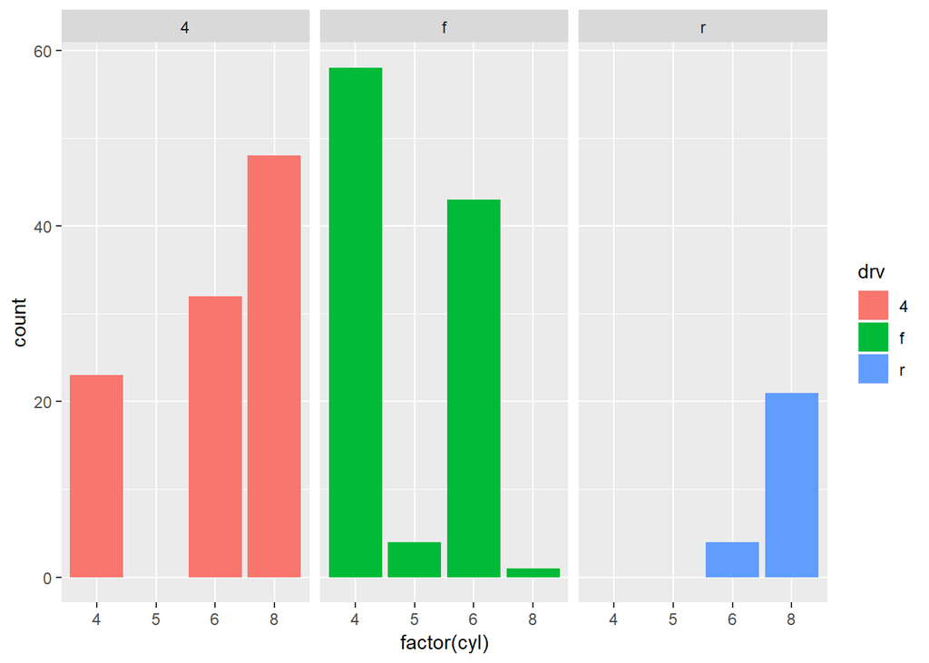

```r
ggplot(mpg, aes(factor(cyl), fill= drv)) + geom_bar() + facet_wrap(~drv)
```

### drv 별로 cyl의 분포

```r
#drv 별로 hwy의 분포
mpg %>% group_by(drv) %>% summarise(min(hwy),max(hwy))
```

```
## # A tibble: 3 x 3
##   drv   `min(hwy)` `max(hwy)`
##   <chr>      <dbl>      <dbl>
## 1 4             12         28
## 2 f             17         44
## 3 r             15         26
```

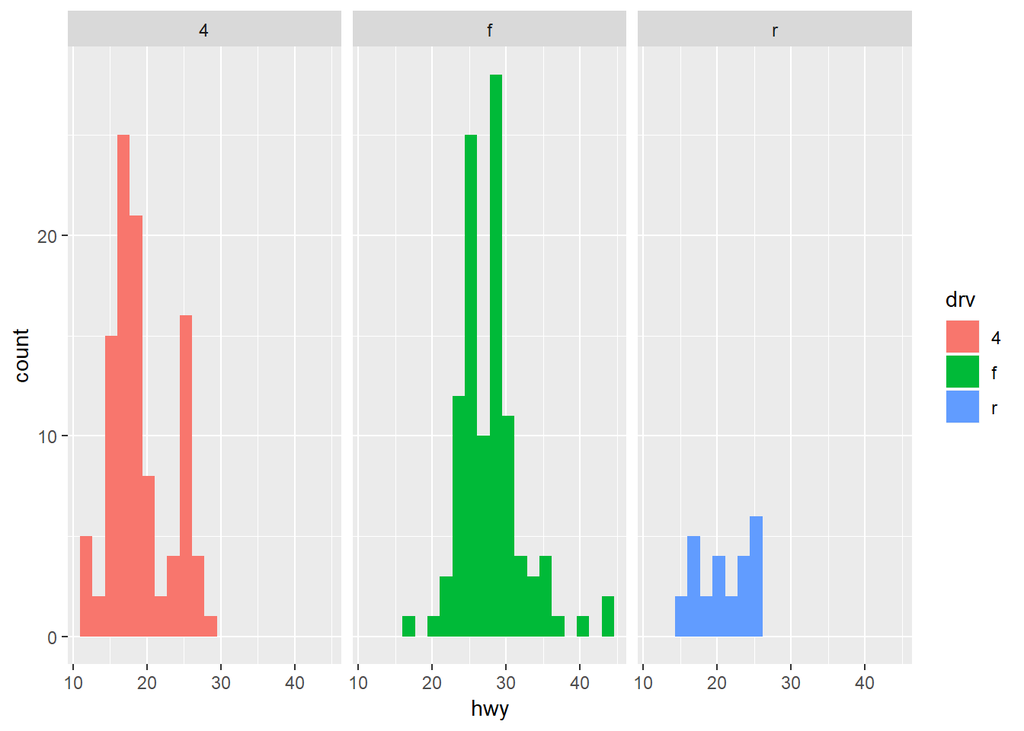

```r
ggplot(mpg, aes(hwy, fill= drv)) + geom_histogram(bins=20) + facet_wrap(~drv)
```

### drv 별로 hwy의 분포

- drv 4는 12<= hwy <= 28 사이에 존재
- drv f는 17<= hwy <= 44
- drv r는 15<= hwy <= 26

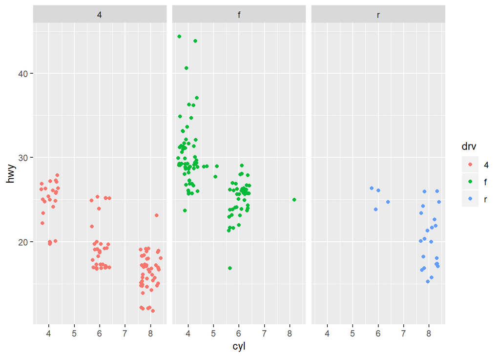

```r
#drv 별로 cyl와 hwy의 분포
ggplot(mpg, aes(cyl, hwy, group= drv)) + geom_jitter(aes(color=drv)) + facet_wrap(~drv)
```

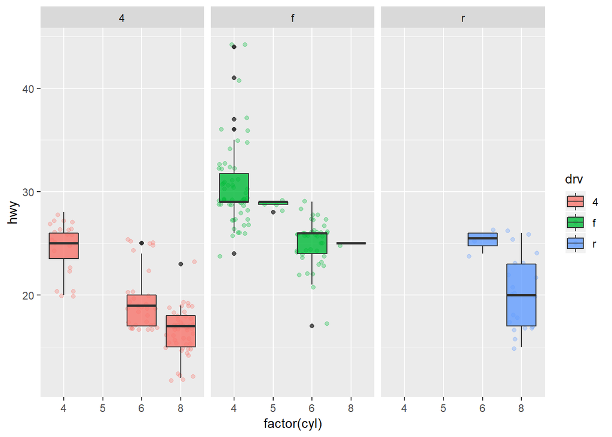

```r
ggplot(mpg, aes(factor(cyl),hwy ))+geom_jitter(aes(color=drv), alpha=0.3)+
  geom_boxplot(aes(fill = drv), alpha=0.8) + facet_wrap(~drv)
```

### drv 별로 cyl와 hwy의 분포

- 모든 drv에서 cyl 이 클수록 hwy 작아지는 경향을 보인다.
- 다만 drv 4와 r dml hwy는 대략 30 이하에 많이 분포된 것에 반해
- drv f의 hwy 는 25이상에 많이 분포하고 있다

# 4.

### mpg 자료의 displ(x변수)와 hwy(y 변수)의 산점도에서 class 별로 선형회귀직선을 그려 아래와 같은 그림을 얻고자 한다. 이에 맞는 code를 작성하시오.

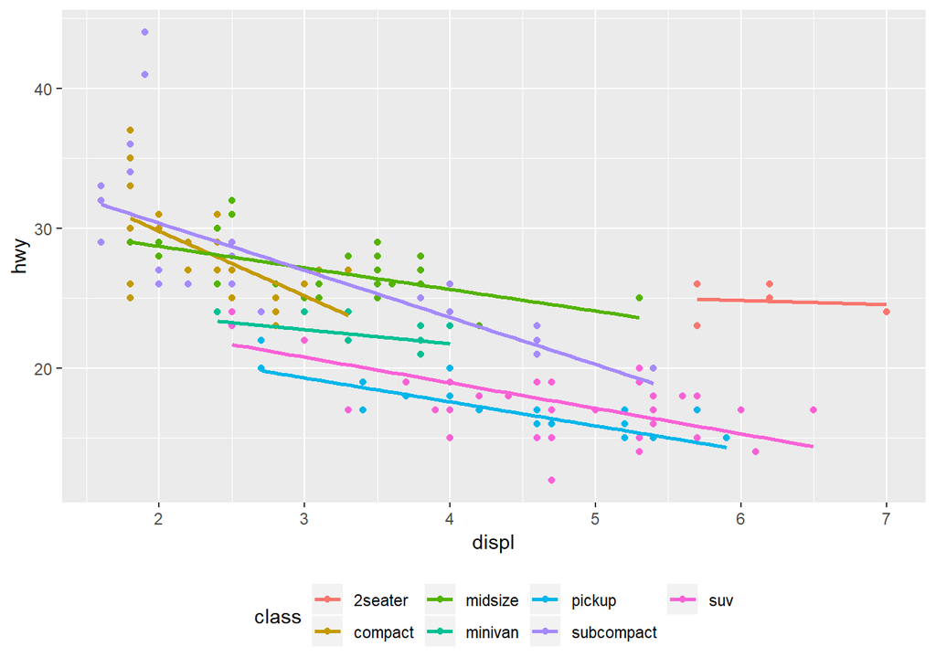

```r
ggplot(mpg, aes(displ, hwy, color=class))+ geom_point()+
  geom_smooth(method="lm", se= FALSE) +
  theme(legend.position = "bottom")
```